# 07_delay_unit_by_age

Kendra Seaman

6/4/2020

# Proportion of Smaller, Sooner Choices by Delay and Age

```
## geom_path: Each group consists of only one observation. Do you need to adjust
## the group aesthetic?
## geom_path: Each group consists of only one observation. Do you need to adjust
## the group aesthetic?
```

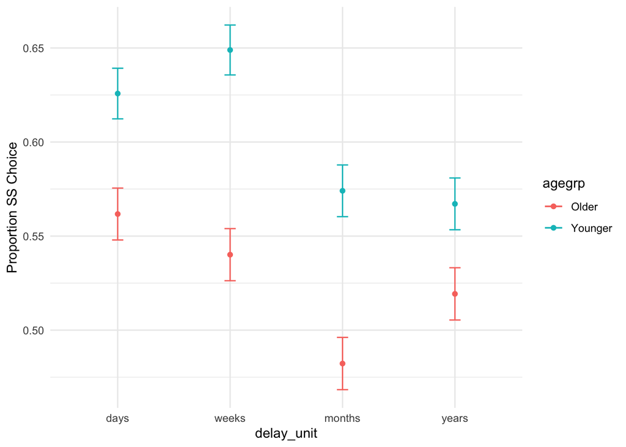

Effect

DFn

DFd

F

p

p<.05

ges

2

Age

1

286

7.141974

0.0079622

0.0193523

3

delay_unit

3

858

10.718162

0.0000006

0.0077992

4

Age:delay_unit

3

858

3.930474

0.0084145

0.0028742

There is main effect of age (which varied between-subjects) with older adults choosing the smaller, sooner option less.

*Mauchley’s test for sphericity:*

Effect

W

p

p<.05

3

delay_unit

0.2899775

0

4

Age:delay_unit

0.2899775

0

Mauchley’s test was significant for all within-subject variable, so use the GGe corrected values below:

*Sphericity Corrections:*

Effect

GGe

p[GG]

p[GG]<.05

HFe

p[HF]

p[HF]<.05

3

delay_unit

0.5558641

0.0000943

0.5587345

0.0000913

4

Age:delay_unit

0.5558641

0.0270310

0.5587345

0.0268266

### Follow-up T-tests within age groups

### Younger

T-Value followed by p value

|  | months | weeks | years |
| --- | --- | --- | --- |
| days | 2.11 | -1.50 | 1.95 |
| months | NA | -4.42 | 0.54 |
| weeks | NA | NA | 3.58 |
| years | NA | NA | NA |

|  | months | weeks | years |
| --- | --- | --- | --- |
| days | 0.037 | 0.1361 | 0.0536 |
| months | NA | 0.0000 | 0.5918 |
| weeks | NA | NA | 0.0005 |
| years | NA | NA | NA |

### Older

T-Value followed by p value

|  | months | weeks | years |
| --- | --- | --- | --- |
| days | 3.64 | 1.53 | 1.47 |
| months | NA | -3.96 | -2.10 |
| weeks | NA | NA | 0.89 |
| years | NA | NA | NA |

|  | months | weeks | years |
| --- | --- | --- | --- |
| days | 4e-04 | 0.1282 | 0.1437 |
| months | NA | 0.0001 | 0.0377 |
| weeks | NA | NA | 0.3770 |
| years | NA | NA | NA |

# Does discounting increase with longer time delays?

No, main effect of delay in both models, however discounting generally decreases with longer time delays.

# Are there age differences for discounting across different delay lengths?

```
##
##  Welch Two Sample t-test
##
## data:  d2$weeks and d3$weeks
## t = 2.8361, df = 285.49, p-value = 0.004894
## alternative hypothesis: true difference in means is not equal to 0
## 95 percent confidence interval:
##  0.0332893 0.1843033
## sample estimates:
## mean of x mean of y
## 0.6489198 0.5401235
```

```
##
##  Welch Two Sample t-test
##
## data:  d2$months and d3$months
## t = 2.307, df = 285.88, p-value = 0.02177
## alternative hypothesis: true difference in means is not equal to 0
## 95 percent confidence interval:
##  0.01347946 0.17016251
## sample estimates:
## mean of x mean of y
## 0.5740741 0.4822531
```

For delays of weeks, younger adults (m=0.65) discount signficantly more than older adults (m= 0.54).  
For delays of months, younger adults (m=0.57) also discount significantly more than older adults (m=0.48).  
There were no significant age differences in days or years.